# 第9回 課題の答え合わせ

基本TODO①〜④と応用①②③

# 基本TODO

## TODO①：累積寄与率

```python
cum = np.cumsum(pca.explained_variance_ratio_)
print(f'上位50個: {cum[49]:.1%}')
for k in [5, 10, 20, 100]:
    print(f'上位{k}個: {cum[k - 1]:.1%}')
```

```
上位50個: 87.4%
上位5個: 54.4%
上位10個: 65.6%
上位20個: 76.3%
上位100個: 93.5%
```

- 上位k個は`cum[k - 1]`。番号は0から

## TODO②：別の顔で

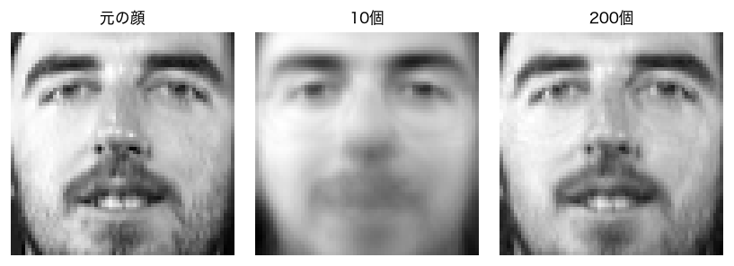

```python
face2 = X[100] - X.mean(axis=0)
fig, axes = plt.subplots(1, 3, figsize=(7, 2.6))
show(axes[0], X[100], '元の顔')
for ax, k in zip(axes[1:], [10, 200]):
    V = pca.components_[:k]
    rec = X.mean(axis=0) + (face2 @ V.T) @ V
    show(ax, rec, f'{k}個')
plt.tight_layout(); plt.show()
```

## TODO③：9割を保つ個数

```python
cum = np.cumsum(pca.explained_variance_ratio_)
k90 = np.argmax(cum >= 0.9) + 1          # 番号は0からなので1を足す
print(k90, round(cum[k90 - 1], 4))
```

```
66 0.9002
```

- 9割を保つのは、66個
- `argmax`は、最初のTrueの番号

## TODO④：個数と、保てる割合

```python
cum = np.cumsum(pca.explained_variance_ratio_)
for k in [20, 50, 66, 100]:
    size = d + d * k + n * k
    print(f'{k:>3}個: {size:>9,} 個（{size / full_size:.1%}）'
          f' 保てる割合 {cum[k - 1]:.1%}')
```

```
 20個:    94,016 個（5.7%） 保てる割合 76.3%
 50個:   228,896 個（14.0%） 保てる割合 87.4%
 66個:   300,832 個（18.4%） 保てる割合 90.0%
100個:   453,696 個（27.7%） 保てる割合 93.5%
```

# 課題

## 保てる割合は見た。正解率は？

- 主成分の数を変えて、見分ける力を比べる

## 応用①：10・50・100個で比べる

```python
accs = {}
for k in [10, 50, 100]:
    pipe_k = Pipeline([('pca', PCA(n_components=k, random_state=0)),
                       ('model', LogisticRegression(max_iter=2000))])
    accs[k] = cross_val_score(pipe_k, X, y, cv=5).mean()
    print(k, round(accs[k], 3))
```

```
10 0.872
50 0.972
100 0.97
```

## 結果を、辞書に集める

- `accs[k] = …`で、主成分の数をキーにして正解率をためる
- あとで、キーで取り出せる

## 応用②：初めて0.95を超えるのは

```
答え: 50
```

- 10個は0.872、50個で0.972
- 正答は50

## 50個から先は、横ばい

- 50個0.972、100個0.970
- 増やしても、正解率は上がらない

## 応用③：模範例

正解率は、10個で0.872、50個で0.972、100個で0.970でした。10個から50個へは大きく上がりますが、50個から100個へはほとんど変わりません。

累積寄与率も、10個で約66%、50個で約87%、100個で約94%と、50個を過ぎると伸びが小さくなります。

持つ数と正解率の釣り合いから、主成分は50個程度で持つのがよいと考えます。

## 書き方の型

- 1段落目：正解率の変わり方
- 2段落目：累積寄与率の伸び方
- 3段落目：開発チームへの提案

# まとめ

## まとめと、発展動画へ

- 累積寄与率は`np.cumsum`、最初のTrueは`np.argmax`
- 主成分は、多ければよいわけではない

発展動画：固有顔の向きに、顔を動かしてみる。